# 00-midterm-inclass

**In addition**, create an input that lets the user choose a variable (either `beer_servings`, `spirit_servings`, and `wine_servings`) and create an output that is a histogram based on that variable.

```r
library(shiny)
library(tidyverse)
library(ggrepel)
library(here)

alcohol_df <- read_csv(here("data/alcohol.csv"))
allcountries_df <- alcohol_df %>% group_by(country) %>% summarise()
vars_df <- alcohol_df %>% names %>% .[c(2, 3, 4)]

library(shiny)

ui <- fluidPage(
  selectInput(inputId = "countrychoice", label = "Select a Country",
              choices = allcountries_df),
  plotOutput("scatterplot"),
  selectInput(inputId = "varchoice", label = "Choose a variable",
              choices = vars_df),
  plotOutput("histplot")
)

server <- function(input, output, session) {

  onecountry_df <- reactive({
    alcohol_df %>% filter(country == input$countrychoice)
  })

  output$scatterplot <- renderPlot({

    ggplot(alcohol_df, aes(x = beer_servings, y = wine_servings)) +
      geom_point() +
      geom_label_repel(data = onecountry_df(), aes(label = country)) +
      geom_point(data = onecountry_df(), size = 3, shape = 1)
  })

  output$histplot <- renderPlot({
    ggplot(data = alcohol_df, aes_string(x = input$varchoice)) +
      geom_histogram()
  })

}

shinyApp(ui, server)
```

Shiny applications not supported in static R Markdown documents

**Question 6** (10 points). For the following `shiny app`, draw a reactive graph. I think the easiest way to do this would be to hand-draw the graph and hand it in on a piece of paper (there is paper at the front of the room). If you can figure out a way to draw it on your computer, you may do that and push that file to GitHub.

```r
ui <- fluidPage(
  radioButtons("input1"),
  selectInput("input2"),
  numericInput("input3"),
  plotOutput("output1"),
  tableOutput("output2")
)

server <- function(input, output, session) {

  df <- tibble(xvar = c(1, 2, 3), yvar = c("a", "b", "c"))

  newval <- reactive({
    input$input1 - input$input2
  })

  anotherval <- reactive({
    log(input$input1)
  })

  output$output1 <- renderPlot({
    plot(newval())
  })

  output$output2 <- renderTable({
    table(df[[input$input3]])
  })
}

shinyApp(ui, server)
```

**Question 7** (20 points). Consider again the women’s tennis data set, `wta_matches_2019.csv`, where each row corresponds to a match played on the WTA (Women’s Tennis Association) tour. Important variables to consider for this problem include:

- `winner_name`, the name of the player who won the match
- `loser_name`, the name of the player who lost the match

Construct a lollipop chart that shows the **10** WTA tennis players with the highest average number of aces in the 2019 season who have played **at least 20 matches**.

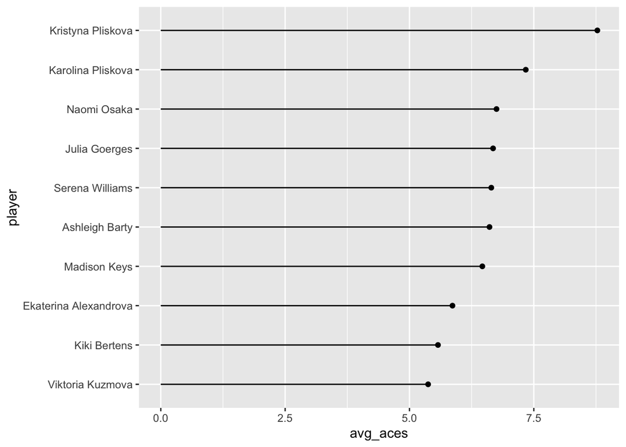

```r
library(tidyverse)
library(here)
wta_df <- read_csv(here("data/wta_matches_2019.csv"))
wta_long <- wta_df %>% pivot_longer(c(winner_name, loser_name),
                                    names_to = "won_or_lost",
                                    values_to = "player") %>%
  select(won_or_lost, player, w_ace, l_ace)

wta_new <-
  wta_long %>%
  mutate(aces = if_else(won_or_lost == "winner_name", w_ace, l_ace)) %>%
  group_by(player)

wta_avg <-
  wta_new %>%
  filter(!is.na(aces)) %>%
  summarise(n_matches = n(), avg_aces = mean(aces))

wta_avg_filter <-
  wta_avg %>%
  filter(n_matches >= 20) %>%
  slice_max(n = 10, avg_aces) %>%
  mutate(player = factor(player)) %>%
  ungroup() %>%
  mutate(player = fct_reorder(player, avg_aces))

ggplot(data = wta_avg_filter, aes(x = player, y = avg_aces)) +
  geom_segment(aes(xend = player, y = 0, yend = avg_aces)) +
  geom_point() +
  coord_flip()
```

**Question 8** (20 points).

**part a.** Consider the lollipop plot you made in **Question 7**. Why is this plot not the best plot to make to look at the top women’s servers in 2019? (There might be a couple of reasons but you should reference one that we have explicitly talked about in class a lot).

The lollipop chart is displaying a summary statistic, but is not doing a good job at showing that there is potential distribution and variability in the statistic. A viewer of this graph may conclude that Pliskova is **always** a better server than Goerges, but surely we could find two games in which Goerges was a better server than Pliskova (and indeed we can).

**part b.** Fix the plot so that it no longer has the issue you described in **Question 8a**.

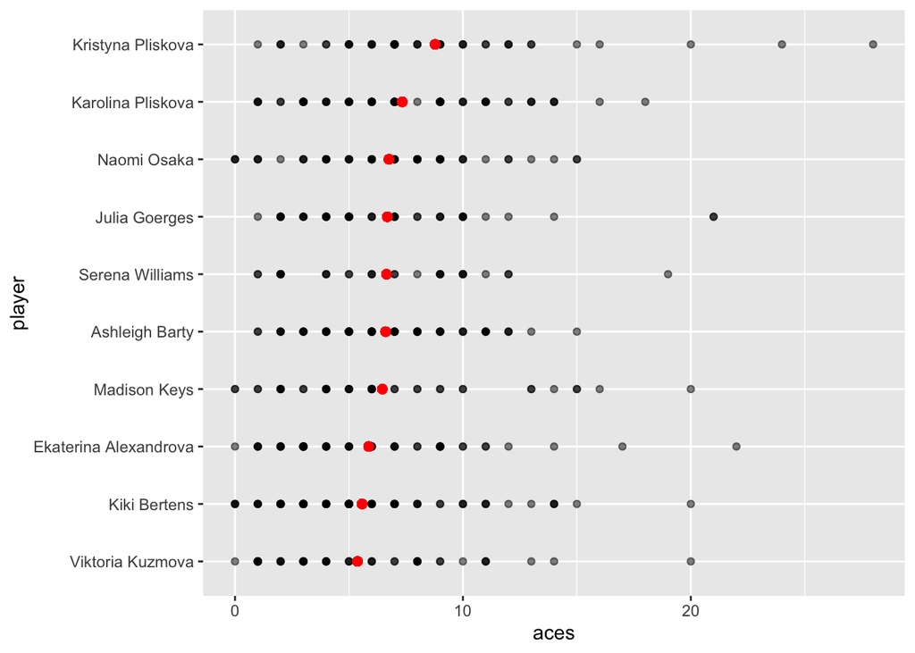

```r
wta_fixed <-
  left_join(wta_new, wta_avg_filter, by = c("player" = "player")) %>%
  filter(!is.na(n_matches)) %>%
  filter(!is.na(aces)) %>%
  ungroup() %>%
  mutate(player = fct_reorder(factor(player), avg_aces))

ggplot(data = wta_fixed, aes(x = player, y = aces)) +
  geom_point(alpha = 0.5) +
  geom_point(aes(y = avg_aces), color = "red", size = 2) +
  coord_flip()
```